# CAPE in using clustered transcripts in multiple tissues

Anna L Tyler

April 27, 2021

```r
#set testing to FALSE to run full gene expression networks and to TRUE
#to run a subset.
#testing = TRUE
testing = FALSE
is.interactive = FALSE
#is.interactive = TRUE
net.type = "signed"
#net.type = "unsigned"

args <- commandArgs(trailingOnly=T)
tissue.type <- args[1]

if(is.na(tissue.type)){
  tissue.type = "Islet"
}
```

The purpose of this workflow is to cluster bulk tissue gene expression from the DO mice with WGCNA.

This workflow cluster transcripts separately in the specified tissue, and runs Islet by default. Other possible tissues are Adipose, Liver, and SkeletalMuscle.

```r
library("here")
all.fun <- list.files(here("Code"), full.names = TRUE, pattern = ".R")
for(i in 1:length(all.fun)){source(all.fun[i])}
```

```r
all.packages <- c("pheatmap", "gprofiler2", "WGCNA", "qtl2")
load_libraries(all.packages)
```

```r
exp.file <- here("Data", "RDS_datasets_tissues", paste0(tissue.type, ".RDS"))
tissue.exp <- readRDS(exp.file)
```

## Filter Expression

Filter the expression matrices to include only genes that have at least a minimum amount of expression.

Here we use the raw expression matrix to select transcripts from the rank Z normalized expression matrix.

```r
min.mean = 10

tissue.trans <- which(colMeans(tissue.exp$data$raw) > min.mean)
tissue.expr <- tissue.exp$data$rz[,tissue.trans]
tissue.covar <- tissue.exp$covar.matrix
adj.expr <- adjust(tissue.expr, tissue.covar)
```

Also collect clinical traits.

```r
pheno <- read.csv(here("Data", "DO_clinical_phenotypes.csv"), stringsAsFactors = FALSE, row.names = 1)
#subset to numeric traits
num.pheno <- apply(pheno[,11:30], 2, as.numeric)
rownames(num.pheno) <- rownames(pheno)
adj.pheno <- adjust(num.pheno, tissue.covar)
gene.table <- tissue.exp$annot.mrna
```

## Cluster gene expression using WGCNA

```r
wgcna.dir <- here("Results", "WGCNA_Clusters", tissue.type)
if(!file.exists(wgcna.dir)){dir.create(wgcna.dir)}
wgcna.net.file <- file.path(wgcna.dir, paste0("net.RDS"))
if(!file.exists(wgcna.net.file)){
  enableWGCNAThreads()

  powers = c(c(1:10), seq(from = 12, to=20, by=2))
  sft = pickSoftThreshold(adj.expr, powerVector = powers, verbose = 5)
  use.power <- sft$powerEstimate
  if(is.na(use.power)){use.power = 6}

  wgcna.net = blockwiseModules(adj.expr, power = use.power, TOMType = net.type,
  minModuleSize = 10, reassignThreshold = 0, mergeCutHeight = 0.25,
  numericLabels = TRUE, pamRespectsDendro = FALSE,saveTOMs = FALSE)

  saveRDS(wgcna.net, wgcna.net.file)
}else{
  wgcna.net <- readRDS(wgcna.net.file)
}

mergedColors = labels2colors(wgcna.net$colors)
wgcna.modules <- wgcna.net$colors

pdf(file.path(wgcna.dir, "Modules.pdf"))
for(i in 1:length(wgcna.net$dendrograms)){
    plotDendroAndColors(wgcna.net$dendrograms[[i]],
  mergedColors[wgcna.net$blockGenes[[i]]], "Module colors",
  dendroLabels = FALSE, hang = 0.03, addGuide = TRUE, guideHang = 0.05)
    }
dev.off()
```

## Characterize Modules

In each tissue we characterized the modules using gprofiler2. We looked for enrichment in all GO domains, as well as KEGG and REACTOME pathways.

The following heatmaps show enriched terms for each set of modules. Shown are the top 10 most significant terms with fewer than 500 genes. The islet enrichment plot only shows the top 5 terms per group, since there are so many modules in this tissue.

```r
module_genes <- function(net.obj){
  modules <- gsub("ME", "", colnames(net.obj$MEs))
  moduleV <- net.obj$colors
  module.genes <- lapply(modules, function(x) names(moduleV)[which(moduleV == x)])
  names(module.genes) <- modules
  return(module.genes)
}

characterize_module <- function(enrich.table, n.terms = 10,
pval_thresh = 0.05, max.term.size = NULL, order.by = "p_value",
decreasing = FALSE){

  low.info.words <- c("to", "of", "the", "process", "or", "by", "in", "and")

  if(length(enrich.table) == 0){return("none")}

  if(length(enrich.table) > 1){
    enrichments <- enrich.table[[1]]
    if(length(max.term.size) > 0){
      term.locale <- which(enrichments[,"term_size"] <= max.term.size)
    }else{
      term.locale <- 1:nrow(enrichments)
    }
    if(length(pval_thresh) > 0){
      sig.locale <- which(enrichments[,"p_value"] <= pval_thresh)
    }else{
      sig.locale <- 1:nrow(enrichments)
    }
    take.locale <- intersect(term.locale, sig.locale)
    all.terms <- enrichments[take.locale,"term_name"]
    if(!is.null(order.by)){
      ordered.terms <- enrichments[order(enrichments[,order.by], decreasing = decreasing),]
    }else{
      ordered.terms <- enrichments
    }
    all.terms <- ordered.terms[,"term_name"]
    term.words <- unique(unlist(strsplit(all.terms, " ")))
    pruned.words <- setdiff(term.words, low.info.words)
    top.words <- pruned.words[1:n.terms]
    mod.description <- paste(top.words, collapse = "-")
    return(mod.description)
  }
}
```

### Module Enrichment

[figure not shown]

```r
module.genes <- module_genes(wgcna.net)
enrich.file <- file.path(wgcna.dir, "enrich.RDS")
if(!file.exists(enrich.file)){
  enrich <- lapply(module.genes, function(x) gost(x, organism = "mmusculus",
  sources = c("GO", "KEGG", "REACTOME")))
  saveRDS(enrich, enrich.file)
}else{
  enrich <- readRDS(enrich.file)
}
mod.names <- sapply(enrich,
function(x) characterize_module(x, n.terms = 5, order.by = "p_value", max.term.size = 500))
#pdf("~/Desktop/islet.enrichment.pdf", width = 9, height = 32)
plot.enrichment.group(enrich, max.term.size = 500, plot.label =
paste(tissue.type, "Modules"), n.terms = 5)
```

```r
#dev.off()
```

## Trait-Module Correlation

We looked at the correlations between each module eigengene and each trait.

```r
mod.eig <- as.matrix(wgcna.net$MEs)
rownames(mod.eig) <- rownames(adj.expr)

#align the phenotype and eigengene matrices
mod.pheno <- get.xz(mod.eig, adj.pheno)
```

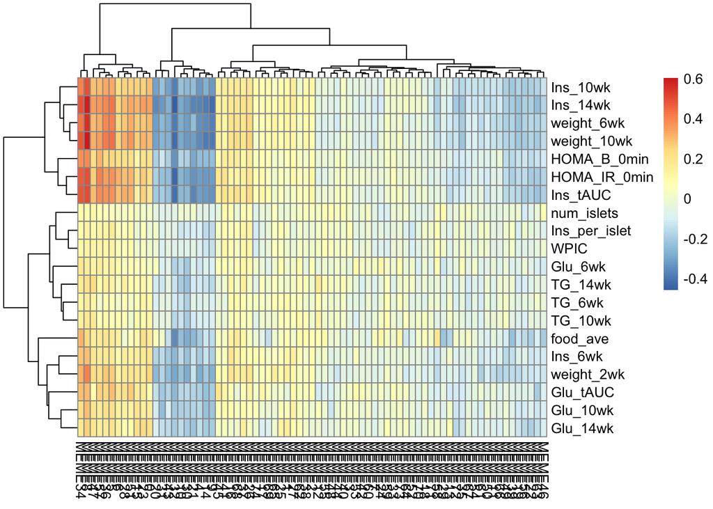

```r
cor.mat <- matrix(NA, nrow = ncol(mod.pheno$X), ncol = ncol(mod.pheno$Z))
rownames(cor.mat) <- paste0("ME", colnames(mod.pheno$X))
colnames(cor.mat) <- colnames(mod.pheno$Z)

for(i in 1:ncol(mod.pheno$X)){
  for(j in 1:ncol(mod.pheno$Z)){
    #plot.with.model(mod.pheno$X[,i], mod.pheno$Z[,j], report = "cor.test")
    mod.trait.cor <- cor(mod.pheno$X[,i], mod.pheno$Z[,j])
    cor.mat[i,j] <- mod.trait.cor
  }
}
pheatmap(t(cor.mat))
```

## Module mapping

```r
#load genotype data
all.var <- ls()
data.loaded <- as.logical(length(which(all.var == "dataset.DO.Cube.Adipose")))
if(!data.loaded){
  load(here("Data", "dataset.DO.CUBE.multissue.RData"))
}
```

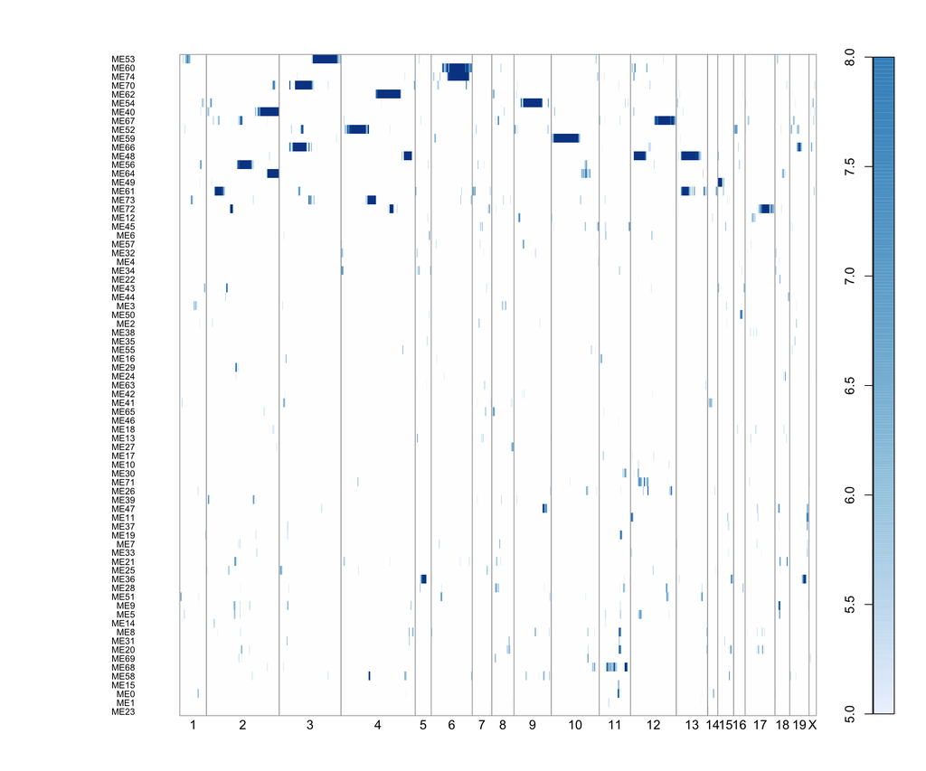

```r
scan.file <- here("Results", "WGCNA_Clusters", tissue.type, "qtl.scan.RDS")
if(!file.exists(scan.file)){
 scans <- scan1(genoprobs, mod.eig)
 saveRDS(scans, scan.file)
}else{
  scans  <- readRDS(scan.file)
}

mod.dist <- dist(t(scans))
mod.order <- hclust(mod.dist)$order
thresh <- scans[,mod.order]
thresh[which(thresh > 8)] <- 8
par(xpd = TRUE)
multilod.plot(thresh, map = map, lod.thresh = 5, border.lwd = 1,
row.names = colnames(mod.eig)[mod.order], row.name.shift = -800,
row.text.cex = 0.7, mar = c(2, 10, 2, 0))
```

```r
par(xpd = FALSE)

#plot(islet.scans, "MEskyblue3", map = map)
#plot(islet.scans, "MEyellowgreen", map = map)
```